# Growth predictions in biogrowth

```r
library(biogrowth)
library(tidyverse)
```

C:6f2837a024701_growth_predictions.R

## The function `predict_growth()`

Growth predictions in **biogrowth** are done using the `predict_growth()` function. It provides a unified interface for making predictions with a variety of modeling approaches. This vignette provides a detailed description of the arguments of `predict_growth()` and how they can be used to make different kinds of model predictions. For a detailed description of the mathematical models available in the package and the computational methods used, please check the relevant vignette.

The `predict_growth()` function has 6 arguments, as well as the `...` argument to pass additional arguments to the functions used for making the predictions. The prediction is defined by the following 6 arguments:

- `times` defines the time points for the calculation of the prediction,
- `primary_model` defines the primary growth model (both the model equation an the values of the model parameters),
- `environment` defines the type of environment. If `environment="constant"`, the predictions are calculated using only a primary model. If `environment="dynamic"`, the function accounts for the effect of variations in the environmental conditions in the specific growth rate through secondary models.
- `secondary_models` defines the secondary growth models for each environmental factor.
- `env_conditions` defines the variation of the environmental conditions during the experiment.
- `formula` defines the column name in `env_conditions` used to state the elapsed time. By default, `formula = . ~ time` indicating that the column is named `time`.

In the following sections, we will describe how these arguments can define different modeling approaches.

Apart from these arguments, the function includes `check`. When `check=TRUE` (default), the function performs several checks of the models (names of the parameters, completeness of the model…) before doing any calculation, returning a warning or error if any inconsistency is detected.

Because the growth of population often spans several orders of magnitude, the models implemented in **biogrowth** are often described in terms of logarithms. The `predict_growth()` function allows the definition of different bases for the logarithm both for the population size and the specific growth rate ($\mu$). This is a common point of confusion when describing population growth, so we encourage the reader to check the specific vignette on the subject.

## Growth predictions under constant environmental conditions

### Basic growth predictions

The argument `environment` defines the type of model that `predict_growth()` will use to calculate the model predictions. When `environment="constant"`, calculations are calculated based only on primary models. The model equation and the values of the model parameters are defined through the argument `primary_model`. It must be a named list with one entry called `"model"` that defines the model equation. The keys identifying the types of model can be retrieved by calling `primary_model_data()`.

```r
primary_model_data()
```

```
#>  [1] "modGompertz"          "Baranyi"              "Baranyi_noLag"
#>  [4] "Baranyi_noStationary" "Trilinear"            "Logistic"
#>  [7] "Richards"             "Loglinear"            "Bilinear_lag"
#> [10] "Bilinear_stationary"
```

C:6f2837a024701_growth_predictions.R

```r
my_model <- "Baranyi"
```

C:6f2837a024701_growth_predictions.R

Then, the values of the model parameters are defined using additional entries in the list. These must be named according to keys defined internally within the package. These (as well as other meta-information on the model) can be retrieved passing the model key to `primary_model_data()`

```r
primary_model_data(my_model)$pars
```

```
#> [1] "logN0"   "logNmax" "mu"      "lambda"
```

C:6f2837a024701_growth_predictions.R

Here we can see that the Baranyi model requires the definition of the logarithm of the initial population size (`logN0`), the maximum population size in the stationary phase (`logNmax`), the growth rate during the exponential growth phase `mu` and the duration of the lag phase `lambda`. In this example, we will assign `logN0=1`, `logNmax=7`, `mu=0.2` and `lambda=20`.

```r
primary_model <- list(model = my_model, logN0 = 1, logNmax = 7, mu = .2, lambda = 20)
```

C:6f2837a024701_growth_predictions.R

For additional details on the model equations and the interpretation of the different model parameters, the reader is referred to the specific vignette about mathematical methods.

For model predictions under constant environmental conditions, the simulations are calculated by solving the algebraic form of the model equation. The time points were it is calculated must be defined using the `times` argument, which is a numeric vector of any length. In this case, we will use a regular vector from 0 to 100 with 1,000 uniformly spaced points.

```r
my_times <- seq(0, 100, length = 1000)
```

C:6f2837a024701_growth_predictions.R

Once we have defined these arguments, we can call the `predict_growth()` function

```r
my_prediction <- predict_growth(environment = "constant", my_times, primary_model)
```

C:6f2837a024701_growth_predictions.R

The function returns an instance of `GrowthPrediction` with several S3 methods to ease the interpretation of the growth prediction. The `print()` method shows the model selected and the values of the model parameters used for the calculations. It also shows the base of the logarithms used for the definition of the model parameters and the population size. This point will be discussed below.

```r
my_prediction
```

```
#> Growth prediction based on primary models
#>
#> Growth model: Baranyi
#>
#> Parameters of the primary model:
#>   logN0 logNmax      mu  lambda
#>     1.0     7.0     0.2    20.0
#>
#> Parameter mu defined in log-10 scale
#> Population size defined in log-10 scale
```

C:6f2837a024701_growth_predictions.R

The values of the model parameters can also be retrieved using the `coef()` method

```r
coef(my_prediction)
```

```
#>   logN0 logNmax      mu  lambda
#>     1.0     7.0     0.2    20.0
```

C:6f2837a024701_growth_predictions.R

It also implements a `plot()` method to visualize the predicted growth curve

```r
plot(my_prediction)
```

[output not shown]

C:6f2837a024701_growth_predictions.R

Note that the y-axis represents the logarithm of the population size. By default, the label of the y-axis shows within parenthesis the base of the logarithm. This, as well as many other aesthetics of the plot, can be edited by passing additional arguments to plot

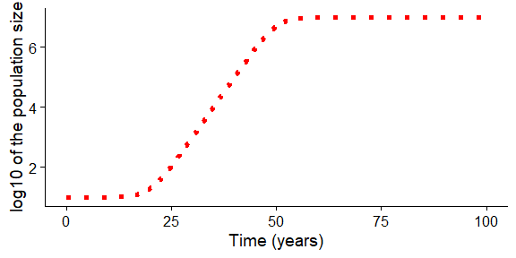

```r
plot(my_prediction,
     label_y1 = "log10 of the population size",
     label_x = "Time (years)",
     line_size = 2,
     line_col = "red",
     line_type = "dotted")
```

C:6f2837a024701_growth_predictions.R

For a detailed description of the arguments admitted by the function, please check its help page (e.g. with `?plot.GrowthPrediction`). Note that `plot()` returns an instance of `ggplot`, so it can be edited using additional layers

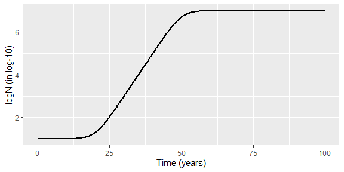

```r
plot(my_prediction) + theme_gray() + xlab("Time (years)")
```

C:6f2837a024701_growth_predictions.R

One aspect that is often of interest when analyzing the growth of populations is the time required to reach a value of the population size. In **biogrowth**, this can be calculated using `time_to_size()`. This function can take as arguments an instance of `GrowthPrediction` and a population size (in log units) and returns the time required to reach that population size.

```r
time_to_size(my_prediction, 3)
```

```
#> [1] 29.97839
```

C:6f2837a024701_growth_predictions.R

If the population size is not reached during the simulation, the function returns `NA`.

```r
time_to_size(my_prediction, 9)
```

```
#> [1] NA
```

C:6f2837a024701_growth_predictions.R

### Alternative definitions of model parameters

Therefore, this model definition is equivalent to the one defined above:

```r
primary_model <- list(model = my_model, logN0 = 1, logNmax = 7, mu = .2, lambda = 20)

Q0 <- lambda_to_Q0(lambda = 20, mu = .2)

equivalent_pars <- list(model = my_model, N0 = 10^1, Nmax = 10^7, mu_opt = .2,
                        Q0 = Q0)

equivalent_prediction <- predict_growth(environment = "constant", my_times,
                                        equivalent_pars)

plot(equivalent_prediction)
```

[output not shown]

C:6f2837a024701_growth_predictions.R

### Definition of different logarithmic bases

As already mentioned above, growth simulations often cover several orders of magnitude, making it more convenient to express the results in logarithmic scale. By default, all the calculations in **biogrowth** are done in log10 scale. Nevertheless, this can be modified using the arguments `logbase_mu` and `logbase_logN`. We believe the relevance of these bases is a common source of confusion when modeling population growth (although the population size has no units, its logarithmic base affects the calculations), so the reader is strongly encouraged to check the vignette dedicated to the unit system.

The base of the logarithm of the population size is defined by `logbase_logN`. By default, the calculations are done in log10 scale, but any numeric value can be passed to this argument. One point worth highlighting here is that the model parameters `logN0` and `logNmax` are defined in the same scale as the population size. Therefore, if the primary model is defined based on this parameters, the growth curve is exactly the same, regardless of the base of $\log N$. The only difference is the label of the y-axis.

```r
primary_model <- list(model = my_model, logN0 = 1, logNmax = 7, mu = .2, lambda = 20)
prediction_base_e <- predict_growth(environment = "constant", my_times,
                                        primary_model,
                                        logbase_logN = exp(1))

prediction_base_e
```

```
#> Growth prediction based on primary models
#>
#> Growth model: Baranyi
#>
#> Parameters of the primary model:
#>   logN0 logNmax      mu  lambda
#>     1.0     7.0     0.2    20.0
#>
#> Parameter mu defined in log-e scale
#> Population size defined in log-e scale
```

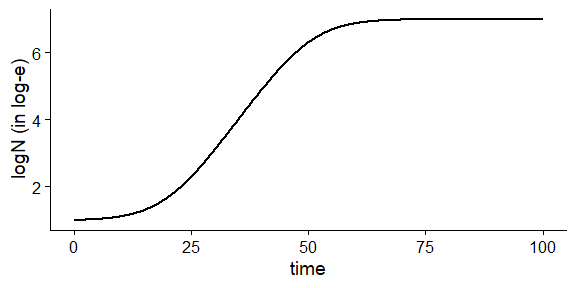

```r
plot(prediction_base_e)
```

C:6f2837a024701_growth_predictions.R

However, if the primary model is defined in terms of $N_0$ and/or $N_{max}$, the growth curve will be affected.

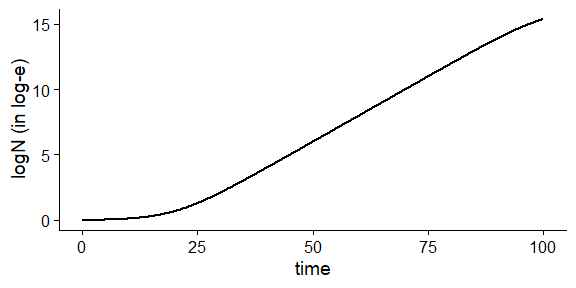

```r
primary_model <- list(model = my_model, N0 = 1, Nmax = 1e7, mu = .2, lambda = 20)
prediction_base_e <- predict_growth(environment = "constant", my_times,
                                        primary_model,
                                        logbase_logN = exp(1))

plot(prediction_base_e)
```

C:6f2837a024701_growth_predictions.R

The base of the logarithm for the parameter $\mu$ is defined by the argument `logbase_mu`. By default, this parameter uses the same base as the population size. Nonetheless, it can accept any numeric value. Changes in this base will be reflected both in the print method and the growth curve:

```r
primary_model <- list(model = my_model, logN0 = 1, logNmax = 7, mu = .2, lambda = 20)
prediction_mu_e <- predict_growth(environment = "constant", my_times,
                                        primary_model,
                                        logbase_mu = exp(1))

prediction_mu_e
```

```
#> Growth prediction based on primary models
#>
#> Growth model: Baranyi
#>
#> Parameters of the primary model:
#>   logN0 logNmax      mu  lambda
#>     1.0     7.0     0.2    20.0
#>
#> Parameter mu defined in log-e scale
#> Population size defined in log-10 scale
```

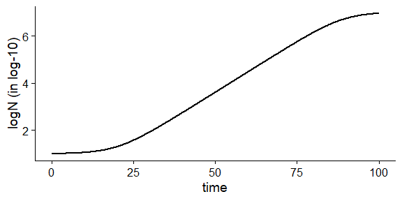

```r
plot(prediction_mu_e)
```

C:6f2837a024701_growth_predictions.R

As detailed in the vignette dedicated to the unit system, the growth rate for different log-bases of $\mu$ can be calculated as $\mu_b = \mu_a \cdot \log_b a$

```r
primary_model <- list(model = my_model, logN0 = 1, logNmax = 7,
                      mu = .2 * log(10),
                      lambda = 20)
prediction_mu_e <- predict_growth(environment = "constant", my_times,
                                        primary_model,
                                        logbase_mu = exp(1)
                                  )

plot(prediction_mu_e)
```

[output not shown]

C:6f2837a024701_growth_predictions.R

Note that `time_to_size()` also accepts a `logbase_logN` argument. By default, this argument takes `NULL`, so the function uses the same logbase as the growth prediction. For instance, if we use `prediction_base_e` that used natural base for the calculation, a `size=5` would mean a size of `exp(5)` units.

```r
print(prediction_base_e)
```

```
#> Growth prediction based on primary models
#>
#> Growth model: Baranyi
#>
#> Parameters of the primary model:
#>     N0   Nmax     mu lambda
#>  1e+00  1e+07  2e-01  2e+01
#>
#> Parameter mu defined in log-e scale
#> Population size defined in log-e scale
```

```r
time_to_size(prediction_base_e, size = 5)
```

```
#> [1] 44.96689
```

C:6f2837a024701_growth_predictions.R

Then, if we want to define the population in log-base10, we would need to set `logbase_logN=10`.

```r
time_to_size(prediction_base_e, log10(exp(5)), logbase_logN = 10)
```

```
#> [1] 44.96689
```

C:6f2837a024701_growth_predictions.R

## Growth predictions under dynamic environmental conditions

The function `predict_growth()` can account for the effect of changes in the environmental conditions on parameter $\mu$. This behaviour is triggered setting `environment="dynamic"`, and requires the definition of additional arguments:

- `secondary_models`, a nested named list that defines the secondary models (models that describe the effect of the changes of the environmental conditions on $\mu$)
- `env_conditions`, a tibble (or data.frame) that describe the variation of the environmental conditions during the experiment.

The dynamic environmental conditions are defined using a tibble (or data.frame). It must have a column defining the elapsed time and as many additional columns as needed for each environmental factor. By default, the column defining the time must be called `time`, although this can be changed using the `formula` argument. For the simulations, the value of the environmental conditions at time points not included in `env_conditions` is calculated by linear interpolation.

In our simulation we will consider two environmental factors: temperature and pH. We can define their variation using this tibble. To illustrate the use of the `formula` argument, we will use `Time` for the column describing the elapsed time.

```r
my_conditions <- tibble(Time = c(0, 5, 40),
                         temperature = c(20, 30, 35),
                         pH = c(7, 6.5, 5)
                         )
```

C:6f2837a024701_growth_predictions.R

Then, the simulations would consider this temperature profile

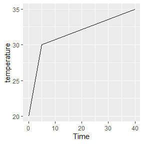

```r
ggplot(my_conditions) +
  geom_line(aes(x = Time, y = temperature))
```

C:6f2837a024701_growth_predictions.R

And this pH profile

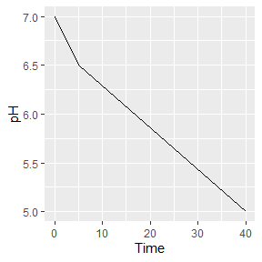

```r
ggplot(my_conditions) +
  geom_line(aes(x = Time, y = pH))
```

C:6f2837a024701_growth_predictions.R

We could define *smoother* profiles using additional rows. For time points outside of the range defined in `env_conditions`, the value at the closes extreme is used (rule=2 from `approx` function).

For dynamic conditions, **biogrowth** uses the Baranyi growth model as primary model. This model requires the definition of two model parameters: the specific growth rate at optimum conditions (`mu_opt`) and the maximum population size (`Nmax`). Moreover, the initial values of the population size (`N0`) and the theoretical substance $Q$ (`Q0`) must be defined. Note that $Q_0$ is related to the duration of the lag phase under isothermal conditions by the identity $\lambda = \ln \left( 1 + 1/q_0 \right)/\mu_{max}$. For the `predict_dynamic_growth()` function, all variables must be defined in a single list:

```r
my_primary <- list(mu_opt = .9,
             Nmax = 1e8,
             N0 = 1e0,
             Q0 = 1e-3)
```

C:6f2837a024701_growth_predictions.R

The next step is the definition of the secondary models. In **biogrowth**, the effect of changes on the environmental conditions in $\mu$ are described based on the gamma concept. In this approach, the effect of each environmental condition ($X_i$) is considered as a correction factor with respect to the one observed under optimal conditions $\mu_{opt}$. Hence, this effect is described by a “gamma” function ($\gamma_i \left(X_i \right)$) that takes values between 0 and 1. For additional details on the mathematical methods, the reader is referred to the specific vignette about mathematical methods.

$$\mu = \mu_{opt} \cdot \gamma_1(X_1) \cdot \gamma_2(X_2) \cdot ... \cdot
\gamma_n(X_n)$$

Therefore, in this example, we need to define one secondary model per environmental condition. This must be done using a list. This list should contain the type of gamma model as well as the model parameters for each environmental condition. The function `secondary_model_data()` can aid in the definition of the secondary models. Calling it without any arguments returns the available model keys.

```r
secondary_model_data()
```

```
#> [1] "CPM"           "Zwietering"    "fullRatkowsky" "Aryani"
#> [5] "Rosso_aw"      "Inhibitory"
```

C:6f2837a024701_growth_predictions.R

For instance, we will define a gamma-type model for temperature as defined by Zwietering et al. (1992). This is done by including an item called `model` in the list and assigning it the value `"Zwietering"`. Then, we define the values of the model parameters. In a similar way as for primary models, passing a model to `secondary_model_data()` returns meta-information of the model, including the parameter keys

```r
secondary_model_data("Zwietering")$pars
```

```
#> [1] "xmin" "xopt" "n"
```

C:6f2837a024701_growth_predictions.R

In this case, we need to define parameters `xmin`, `xopt` and `n` (for a detailed description of the modeling approach, please check the relevant vignette). We define them using individual entries in the list:

```r
sec_temperature <- list(model = "Zwietering",
                        xmin = 25,
                        xopt = 35,
                        n = 1)
```

C:6f2837a024701_growth_predictions.R

Next, we will define a CPM model for the effect of pH. Note that the model selection is for illustration purposes, not based on any scientific knowledge. First of all, we need to set the item `model` to `"CPM"`. Then, we need to define the model parameters (note that this model also needs `xmax`).

```r
sec_pH <- list(model = "CPM",
               xmin = 5.5,
               xopt = 6.5,
               xmax = 7.5,
               n = 2)
```

C:6f2837a024701_growth_predictions.R

The final step for the definition of the gamma-type secondary model is gathering all the individual models together in a single list and assigning them to environmental factors. Each element on the list must be named using the same column names as in `env_conditions`. Before, we had used the column names `temperature` and `pH`. Thus

```r
my_secondary <- list(
    temperature = sec_temperature,
    pH = sec_pH
    )
```

C:6f2837a024701_growth_predictions.R

The final argument is the time points where to make the calculations. We can use a numeric vector with 1000 points between 0 and 50 for this:

```r
my_times <- seq(0, 50, length = 1000)
```

C:6f2837a024701_growth_predictions.R

Once we have defined every argument, we can call the `predict_dynamic_growth()` function. Because we are using `Time` to define the elapsed time in `env_conditions`, we must also define the `.~Time` in the formula argument.

```r
dynamic_prediction <- predict_growth(environment = "dynamic",
                                     my_times,
                                     my_primary,
                                     my_secondary,
                                     my_conditions,
                                     formula = . ~ Time
                                     )
```

C:6f2837a024701_growth_predictions.R

The function returns an instance of `GrowthPrediction` with the results of the simulation. It includes several S3 methods to ease the interpretation of the results. The `print` method shows the models used, as well as the environmental factors considered in the simulation. The print method also shows the log-bases used for the calculations. By default, the functions uses log10 base, but this can be modified using `logbase_mu` and `logbase_logN` as in simulations for constant environmental conditions.

```r
dynamic_prediction
```

```
#> Growth prediction under dynamic environmental conditions
#>
#> Environmental factors included: temperature, pH
#>
#> Parameters of the Baranyi primary model:
#> mu_opt   Nmax     N0     Q0
#>  9e-01  1e+08  1e+00  1e-03
#>
#> Parameter mu defined in log-10 scale
#>
#> Population size defined in log-10 scale
#>
#> Secondary model for temperature:
#>        model         xmin         xopt            n
#> "Zwietering"         "25"         "35"          "1"
#>
#> Secondary model for pH:
#> model  xmin  xopt  xmax     n
#> "CPM" "5.5" "6.5" "7.5"   "2"
```

C:6f2837a024701_growth_predictions.R

Again, the class includes `plot` methods to visualize the growth curve.

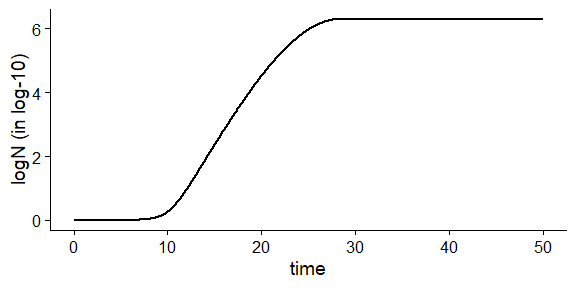

```r
plot(dynamic_prediction)
```

C:6f2837a024701_growth_predictions.R

This plot can include the variation of a single environmental factor alongside the growth curve. As well as above, several aesthetics of the plot can be modified passing additional arguments to the plotting function. Please check the help page of `plot.GrowthPrediction` for a complete list of options.

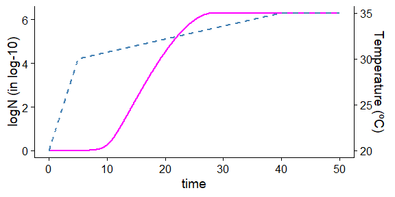

```r
plot(dynamic_prediction,
     add_factor = "temperature",
     line_col2 = "steelblue",
     line_col = "magenta",
     label_y2 = "Temperature (ºC)")
```

C:6f2837a024701_growth_predictions.R

Similar to predictions under constant environmental conditions, `time_to_size` can estimate the time required to reach a given population size:

```r
time_to_size(dynamic_prediction, 3)
```

```
#> [1] 16.36868
```

C:6f2837a024701_growth_predictions.R